# DSS Capstone Project typeRight : prediction app

Karthik Arumugham  
October 01, 2016

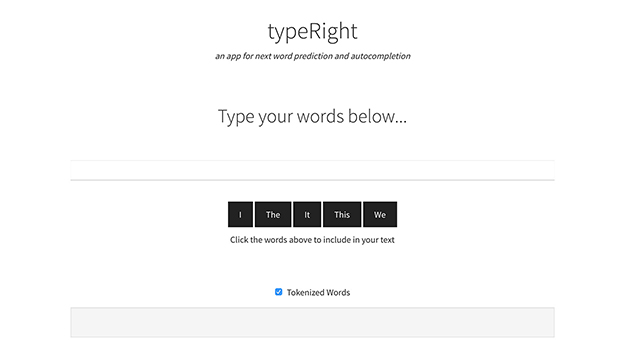

### Data Cleaning

- I used the *English* files from the **HC Corpora** dataset, which contains ~4M lines of text from news articles, Twitter, and blogs
- *Regular Expression* was used to clean and tokenize the raw text,
  - replaced `_PHONE_`, `_URL_`, `_EMAIL_`, `_DATE_`, `_TIME_`, `_NUM_`, & `_VULGAR_`
  - removed repeated and other punctuation marks and spaces
- *Preserved sentence structure* by retaining a few characters,
  - apostrophes like `I'm`, `America's`, etc
  - punctuation marks like `,` and `-`
  - upper case letters like `I`,`Obama`, etc
- Tried sentence boundary tags. But later dropped it due to performance issues.

### Data Analysis & Structure

- Explored with `RWeka` and `ngram` packages to tokenize data and build ngrams. Also *built from scratch* a code for ngrams. However, `ngram` package offered the highest performance
- Used *parallel processing* with `foreach` and `snow` packages by splitting corpus into 6000 fragments
- *Stored and Indexed* the 5-gram table using `data.table` package for *fast retrieval due to indexing and binary search*
- Randomly sampled ~1% of all three of the blogs, news, and twitter dataset to test the code. Built the final algorithm using 100% of the corpus
- The final ngram table is pruned to limit to 93MB when loaded in memory to increase performance when hosted on shinyapps.io

### Prediction Algorithm

- The model cleans/tokenizes the input first, and are fed through two algorithms
  - **Autocomplete**: take the last group of letters from the input, look up words in the `unigram` table that start with the letters, and return the result with the highest frequency
  - **Prediction**: look up the last 4 words in `fivegram` table, last 4 words in the `fourgram`, etc in order, sorted by probability.
  - Tried **Maximum Likelihood Estimation (MLE)** on all four N-gram tables by setting weights by trail, but resulted only in marginal improvements in accuracy on all occasions. \[ p = 0.4\frac{Count(w_{i−4},w_{i−3},w_{i−2},w_{i-1},w_i)}{Count(w_{i−3},w_{i−3},w_{i-2},,w_{i-1},w_i)} + 0.3\frac{Count(w_{i−3},w_{i−2},w_{i−1},w_i)}{Count(w_{i−2},w_{i−1},w_i)} + 0.2\frac{Count(w_{i−2},w_{i−1},w_i)}{Count(w_{i−1},w_i)} + 0.1\frac{Count(w_{i−1},w_i)}{Count(w_i)} \]
- Got a overall top-3 score of 17.52 % in the [benchmark](https://github.com/jan-san/dsci-benchmark/) test for 28,464 predictions and 50% for the quiz questions.

### Shinyapp & Instructions

- The final product can be found [here](https://karthiaru.shinyapps.io/word-prediction/)
- The following are the features of the app
  - predicted autocomplete words will appear as you type
  - predicted next word will appear when you provide a space
  - click the words to add to your text
  - view optional *Tokenized Text*